# Military Education Exchange - Network Analysis

## Introduction

The FME literature generally treats FME relationships in a dyadic manner (e.g. Ruby and Gibler 2010; Omelicheva et al. 2017). In other words, authors often seek to measure the effect that a sponsor’s FME relationship has on a recipient state’s domestic or foreign policy (e.g. Atkinson 2014; Martinez Machain 2021). However, FME relationships between states provide interpersonal contacts between the states’ military members. As such, FME relationships create a social network between military members of various states. As Hafner-Burton, Kahler, and Montgomery (2009) point out, network structures, or the patterns of interactions between agents [states] over time “can define, enable, and constrain those agents” (p. 559). For the purpose of this analysis, we will primarily focus on the states which the military members represent, and therefore I will treat the states as the nodes. Their ties are their FME relationships. We are particularly interested in communities and how communities enable and constrain sponsors and recipients. A community has relatively dense ties with one another and has less ties with other groups. Network analysis will allow us to move beyond dyadic relationships and see if and how the network structure impacts how FME sponsorship may affect recipient states’ foreign policy.

## Edgelist

The edge list shows the connections between different countries. To compile the edge list, we counted the total number of FME relationships between two countries (either sponsor-recipient or recipient-sponsor). In other words, if 3x individuals from Tanzania were trained in South Africa and 1x individual from South Africa was trained in Tanzania, this was counted as a weighted edge of 4 for the South Africa-Tanzania pair.

In the graph below, we can see the set of edges, and the number of nodes and edges. Here, nodes correspond to countries and edges correspond to military education exchange between countries (i.e., whether a leader from a particular country has engaged military education exchange with another country).

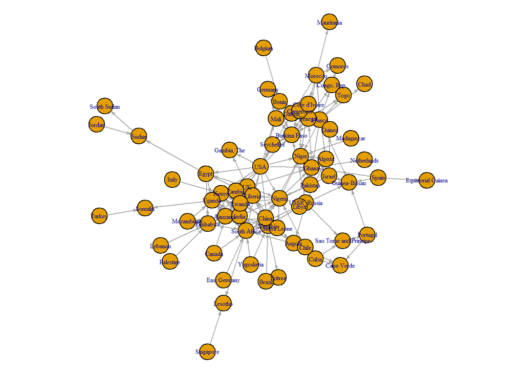

```r
edgelist <- read.csv("edgelist.csv")
h <- as.matrix(edgelist[,1:2])
i <- graph_from_edgelist(h)

par(mar=c(0,0,0,0))
    plot(i, vertex.size=10, vertex.label.cex=0.5, edge.arrow.size=.25)
```

```r
E(i)$weight<-edgelist[,3]
```

## Network Statistics

- The *density* of a network is the ratio of the number of edges to the the number of possible edges. In other words, the proportion of present edges to all possible edges in the network. A dense network indicates a high number of ties between many of the nodes. A less dense network means that there are fewer shared ties among all the nodes.
- *Transitivity* is a measure of the tendency of the nodes to cluster together. High transitivity means that the network contains communities or groups of nodes that are densely connected internally.
- *Network diameter* is the longest geodesic distance (length of the shortest path between two nodes) in the network. In igraph, diameter() returns the distance, while get_diameter() returns the nodes along the first found path of that distance. Note that edge weights are used by default, unless set to NA.
- *Average path length* is the mean of the shortest distance between each pair of nodes in the network (in both directions for directed graphs).

## FME Network Statistics

```r
#Total nodes: 69
vcount(i)

#Total edges: 160
ecount(i)

#Density of graph: 0.068
graph.density(i,loops = F)

#Transitivity: 0.217
transitivity(i,type = "global")

#Diameter: 8
diameter(i)
diameter(i, weights = NA) #7 unweighted
diam <- get_diameter(i)
diam
```

[output not shown]

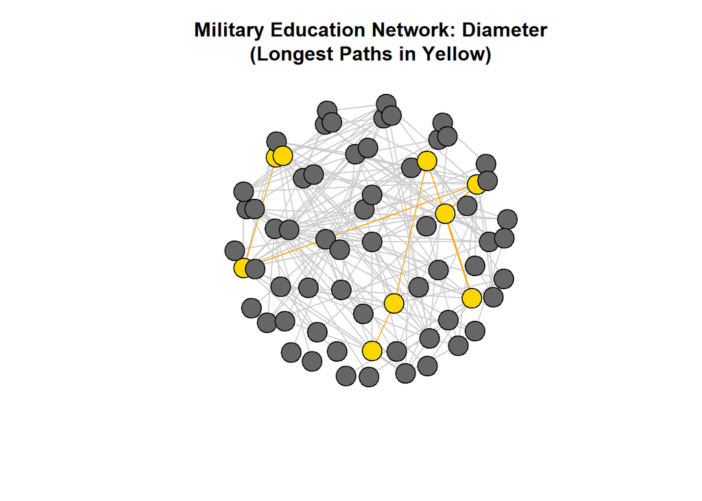

```r
vcol <- rep("gray40", vcount(i))
vcol[diam] <- "gold"
ecol <- rep("gray80", ecount(i))
ecol[E(i, path=diam)] <- "orange"
plot(i,layout=layout.sphere, vertex.color=vcol, edge.color=ecol, edge.arrow.mode=0, vertex.label=NA, mfrow=c(1,1), main = "Military Education Network: Diameter\n(Longest Paths in Yellow)")
```

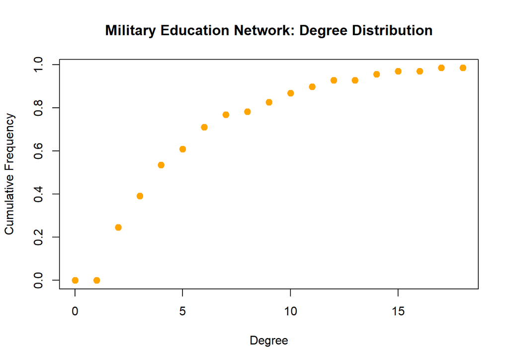

```r
#degree distribution
deg_dist <- degree_distribution(i, cumulative=T, mode="all")
plot(x=0:max(degree(i)), y=1-deg_dist, pch=19, cex=1.2, col="orange",
xlab="Degree", ylab="Cumulative Frequency", main = "Military Education Network: Degree Distribution")
```

- In network analysis, a clique is a sub-set of a network in which the actors are more closely and intensely tied to one another than they are to other members of the network.The plot below shows the largest cliques in the military education exchange network in yellow, which shows the clique with the the most concentrated degree distribution & density.

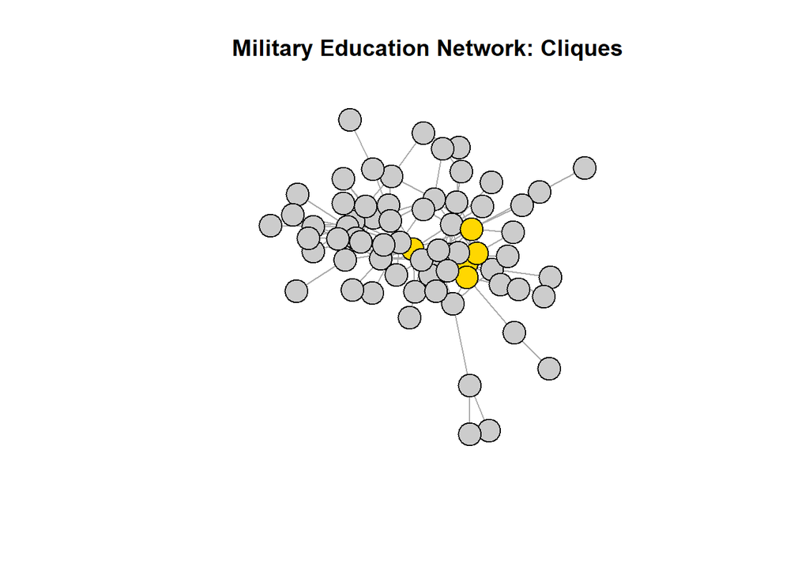

```r
#mean distance
mean_distance(i) #3.04
#distances(i) # with edge weights
#distances(i, weights=NA) # ignore weights

#cliques
vcol <- rep("grey80", vcount(i))
vcol[unlist(largest_cliques(i))] <- "gold"
plot(as.undirected(i), vertex.label=NA, vertex.color=vcol, main = "Military Education Network: Cliques")
```

## Network Visualization

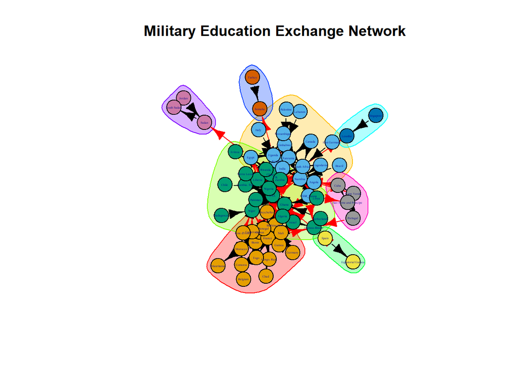

```r
wk <- walktrap.community(i)
df <- as.data.frame(table(wk$membership))
names(df) <- c("Community Number", "Size")
kable(df,caption = "Communities in the Network")

#table(wk$names, wk$membership)
#class(wk)

#memb <- membership(wk)
#class(memb)
#attributes(memb)
#wk$membership

GroupNum<-wk$membership
Names<-attr(membership(wk), "names")
Memb.df<-cbind(GroupNum, Names)
Memb.df<-cbind(GroupNum, Names)
Memb.df<-as.data.frame(Memb.df)
library(dplyr)
Memb.df%>%arrange(GroupNum)


nodes <- data.frame(id = V(i)$name, title = V(i)$name, group = wk$membership)
edges <- get.data.frame(i, what="edges")[1:2]

vis.nodes <- nodes
vis.links <- edges
vis.nodes$shape  <- "dot"
vis.nodes$shadow <- TRUE
vis.nodes$title  <- V(i)$name
vis.nodes$label  <- V(i)$name
vis.nodes$size   <- 35
vis.nodes$borderWidth <- 2

vis.links$width <- 3
vis.links$font.size <- 15
vis.links$label <- E(i)$weight
vis.links$dashes <- as.vector(ifelse(E(i)$weight==1,TRUE,FALSE))
vis.links$color <- palette()[E(i)$weight]
vis.links$arrows <- "to" # arrows: 'from', 'to', or 'middle'
vis.links$smooth <- FALSE
vis.links$shadow <- FALSE
vis.nodes$color.border <- "black"
vis.nodes$color.highlight.background <- "orange"
vis.nodes$color.highlight.border <- "darkred"

 k <- visNetwork(vis.nodes, vis.links, width = "100%", height = 700) %>%
visIgraphLayout(layout = "layout.sphere")

ledges <- data.frame(color = palette()[unique(E(i)$weight)], label =unique(E(i)$weight))
visLegend(k, main="Communities",addEdges = ledges, position="left", ncol=3)

wolf <- plot(wk,i, vertex.label.cex =0.25, main = "Military Education Exchange Network", labels = TRUE)
```

[output not shown]

The two largest communities, 2 and 3, are comprised of the following:

Community 2 is comprised of Egypt, Kenya, UK, Namibia, USSR_Russia, Angola, South Africa, Uganda, Zimbabwe, Tanzania, India, Mozambique, Yugoslavia, Lebanon, Palestine, Canada, East Germany, Brazil, and Italy. The presence of both the UK and Russia within the same community is interesting and can possibly be explained in part by those countries’ histories of military or colonial involvement in the countries in this community.

Community 3 includes USA, Gambia, Ghana, Liberia, Israel, Niger, Nigeria, Algeria, Guinea-Bissau, China, Sierra Leone, Netherlands, Eritrea, Pakistan, Zambia, Libya, Chile, Madagascar, and Rwanda. What is interesting that the USA and China are in the same community, suggesting that other countries within this community tend to engage in military education exchange with both of them, even though they are adversaries.

## Geographic Network Visualization

The map below displays the network communities geographically. The geographic display highlights the major powers in the Liberal International Order (the US and Western Europe) as well as the emerging powers, BRICS (Brazil, Russia, India, China, and South Africa), are all tied into the African FME network. France appears to have maintained connections with its former colonial empire in Africa. Similarly, the UK does as well to some extent, although it appears to compete for influence with Russia. Furthermore, several Commonwealth nations to include India and Canada are integrated into the community - perhaps due to their ties wtih the UK. Interestingly, the US, China, and Pakistan are within the same community. Perhaps this is indicative of the level of competition within these countries as the US and China also have several ties to the first two communities as well. Finally, this map shows that smaller powers such as Spain, Singapore, Turkey, Portugal, and Cuba may actively seek out FME relationships with smaller African countries that the major powers are less interested in.

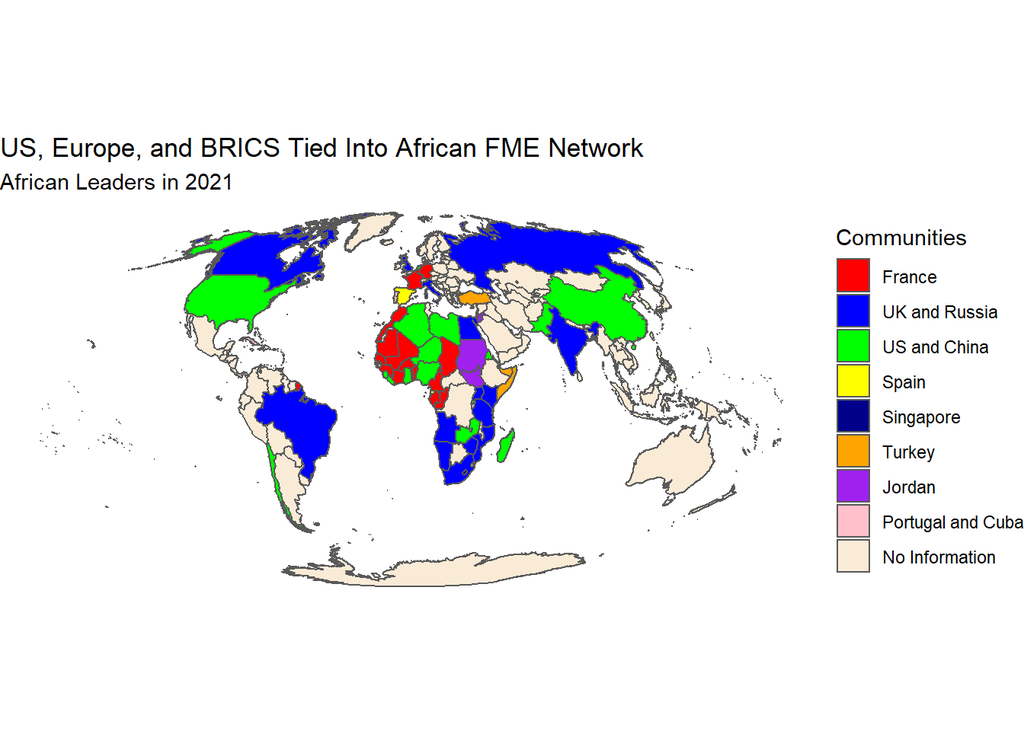

```r
library(sf)
world <- read_sf("countries.geojson")
membership <- read_csv("Membership.csv")

membership_map <- left_join(world,
                            membership,
                            by=c("ADMIN" = "Names"))

membership_map %>%
  st_transform("+proj=moll") %>%
  ggplot()+
  geom_sf(aes(fill=factor(GroupNum)))+
  scale_fill_manual(
    na.value = "antiquewhite",
    values = c("red", "blue", "green", "yellow", "dark blue", "orange", "purple", "pink"),
    name = "Communities",
    labels = c("France",
               "UK and Russia",
               "US and China",
               "Spain",
               "Singapore",
               "Turkey",
               "Jordan",
               "Portugal and Cuba",
               "No Information")) +
  labs(title="US, Europe, and BRICS Tied Into African FME Network", subtitle = "African Leaders in 2021") +
  theme_void()
```

The below visualization of communities as restricted to the African continent allows us to see how important geographic contiguity appears to be. Certainly, the French community is split in two. Similarly, the UK/Russian community is split into Egypt and southern, coastal Africa. Nonetheless, most African countries within a community border others within the same community. One would expect African states to interact more with their neighbors than states that are further away. This logic does not apply for the interactions of great powers, like the US or China, who are operating at a great distance with all African states. Therefore, geographic contiguity highlights the importance of relationships between African countries to influence community formation and maintenance.

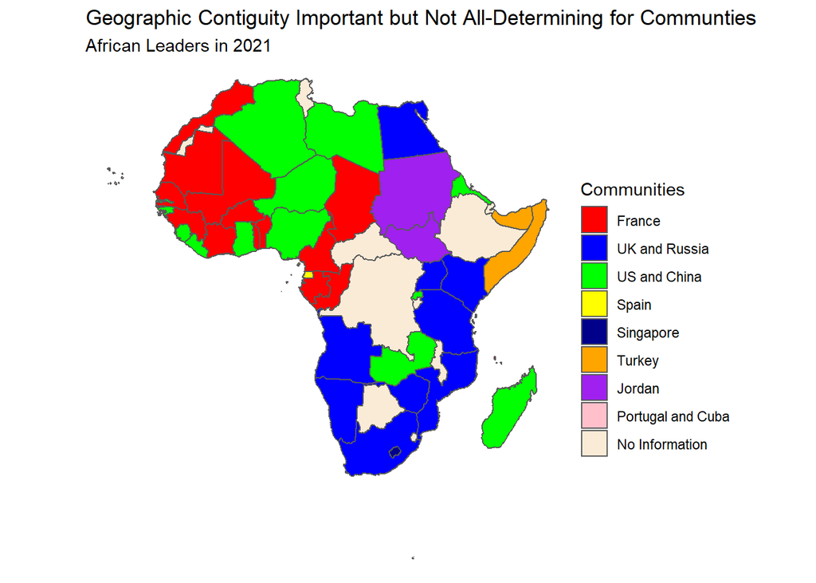

```r
africa_map <- st_read("africa_adm0.geojson")

membership_map_africa <- left_join(africa_map,
                            membership,
                            by=c("adm0_a3" = "Codes"))

membership_map_africa %>%
  st_transform(crs=5523) %>%
  ggplot()+
  geom_sf(aes(fill=factor(GroupNum)))+
  scale_fill_manual(
    na.value = "antiquewhite",
    values = c("red", "blue", "green", "yellow", "dark blue", "orange", "purple", "pink"),
    name = "Communities",
    labels = c("France",
               "UK and Russia",
               "US and China",
               "Spain",
               "Singapore",
               "Turkey",
               "Jordan",
               "Portugal and Cuba",
               "No Information")) +
  labs(title="Geographic Contiguity Important but Not All-Determining for Communties", subtitle = "African Leaders in 2021") +
  theme_void()
```

## Centrality

In graph theory and network analysis, methods of centrality assign numbers or rankings to nodes within a graph corresponding to their network position. Applications include identifying the most influential person(s) in a social network, key infrastructure nodes in the Internet or urban networks, super-spreaders of disease, and brain networks, for example. Centrality measures are explored below as a way to identify the most influential countries in our network.

```r
#Centrality table
Degree <- degree(i,mode = "all")
Betweenness <- betweenness(i)
Closeness <- closeness(i)
df <- data.frame(Degree, Betweenness, Closeness)
kable(df,caption = "Centrality Score for each Network")
```

[output not shown]

### Degree Centrality

The degree centrality of a node is simply its degree—the number of edges it has. The higher the degree, the more central the node is. This can be an effective measure, since many nodes with high degrees also have high centrality by other measures.

In our network, the top five nodes by degree centrality are the USA, France, South Africa, Namibia, and Nigeria.

In the visualization below, we can see that the USA and France are the top two nodes in terms of degree centrality.

```r
#Top 5 nodes by Degree centrality
sort(degree(i,mode = "all"),decreasing = TRUE)[1:5]
```

```
##          USA       France South Africa      Namibia      Nigeria
##           18           16           14           13           13
```

```r
## Network Visualization By Degree
nodes <- data.frame(id = V(i)$name, title = V(i)$name, group = wk$membership)
edges <- get.data.frame(i, what="edges")[1:2]

vis.nodes <- nodes
vis.links <- edges
vis.nodes$shape  <- "dot"
vis.nodes$shadow <- TRUE
vis.nodes$title  <- V(i)$name
vis.nodes$label  <- V(i)$name
vis.nodes$size   <- Degree * 3
vis.nodes$borderWidth <- 2

vis.links$width <- 3
vis.links$font.size <- 15
vis.links$label <- E(i)$weight
vis.links$dashes <- as.vector(ifelse(E(i)$weight==1,TRUE,FALSE))
vis.links$color <- palette()[E(i)$weight]
vis.links$arrows <- "to"
vis.links$smooth <- FALSE
vis.links$shadow <- FALSE
vis.nodes$color.border <- "black"
vis.nodes$color.highlight.background <- "orange"
vis.nodes$color.highlight.border <- "darkred"

 k <- visNetwork(vis.nodes, vis.links, width = "100%", height = 700, main = "Network Visualization by Degree centrality") %>%
visIgraphLayout(layout = "layout.sphere")

ledges <- data.frame(color = palette()[unique(E(i)$weight)], label =unique(E(i)$weight))
visLegend(k, main="Communities",addEdges = ledges, position="left", ncol=3)
```

[interactive chart not shown]

### Betweenness Centrality

Betweenness centrality quantifies the number of times a node acts as a bridge along the shortest path between two other nodes, that is, betweenness centrality ranks the importance of a node in terms of its role as a “bridge”connecting other nodes.

The top five nodes by betweenness centrality in this network are the USA, France, Niger, South Africa and Namibia. In other words, countries tend to engage in military education exchange with countries that are connected (i.e, have engaged in education exchange) with the USA, France, Niger, South Africa, and Namibia.

```r
#Top 5 nodes by Betweenness Centrality
sort(betweenness(i,directed = FALSE),decreasing = TRUE)[1:5]
```

```
##          USA       France        Niger South Africa      Namibia
##     653.2415     388.4880     361.3632     318.6604     316.0140
```

### Closeness Centrality

Closeness centrality indicates how close a node is to all other nodes in the network. It is calculated as the average of the shortest path length from the node to every other node in the network.

In our network, the top five nodes by closeness centrality are the USA, Niger, Nigeria, Burkina Faso, and South Africa, in that order.

```r
#Top 5 nodes by closeness centrality
sort(closeness(i,mode = "all"),decreasing = TRUE)[1:5]
```

```
##          USA        Niger      Nigeria Burkina Faso South Africa
##  0.006410256  0.006024096  0.005917160  0.005586592  0.005555556
```

## [Navigation Page](https:///eml129.github.io/PPOL670_FinalProject_FME/)